# Praca domowa 5

Damian Gutowski

21 listopada 2018

## Cel zadania

Celem zadania było zbadanie, czy w społeczeństwie występują problemy z czytaniem wykresów przygotowanym nie trzymając się dobrych praktych.

## Przygotowany eksperyment

Na potrzeby zadania przygotowano dwa wykresy. Pierwszy z nich, mimo iż przedstawia te same dane jest niepoprawny, bo przygotowany bez uwzględnienia dobrych praktyk. Drugi został przygtowany znacznie bardzie starannie, tak aby był bardziej czytelny. Inspiracją do zadania była jedna z poprawionych prac domowych oraz pewnien wykres znaleziony na stackoverflow. W ramach eksperymentu pokazano badanym pierwszy, niepoprawny wykres i zadano trzy pytania, na które odpowiedź była trudna. Potem przedstawiono ankietyzowanemu drugi wykres i zadano ponownie te same pytania. Dane użyte w zadaniu były prawdziwe, z jednym wyjątkiem. Dodano jeden bank (nie istniejący już) ze znacznie gorszą ofertą od razu rzucającą w oczy.

## Pierwszy wykres

W przygotowanej ankiecie wykres był większy, więc nazwy bankóW się nie zlewały.

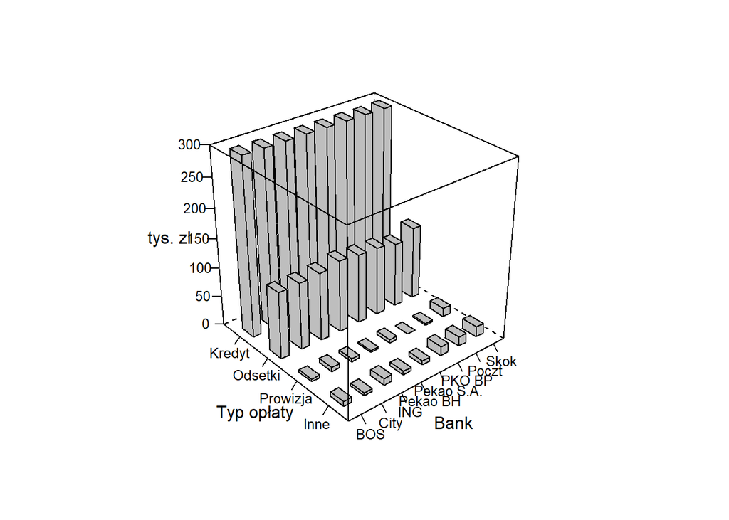

```r
dt <- data.table(read.csv2("kredyty.csv", stringsAsFactors=FALSE))
names(dt)[1]<-"Bank"
tmp <- data.table(melt(dt[,-2], id="Bank"))
tmp <- tmp[order(value)]
tmp[,3] <- tmp[,3]/1000
minprice <- min(dt[,2])/1000

tmp$Bank <- factor(tmp$Bank)


cloud(value~Bank+variable, tmp, panel.3d.cloud=panel.3dbars, col.facet='grey',
      ylab="Typ opłaty", zlab = "tys. zl",
      xbase=0.4, ybase=0.4, scales=list(arrows=FALSE, col=1),
      par.settings = list(axis.line = list(col = "transparent")))
```

## Drugi wykres

```r
dt <- data.frame(read.csv2("kredyty.csv", stringsAsFactors=FALSE))
names(dt)[1]<-"Bank"
dt[,2] <- dt[,2] - dt[,6]
dt[,1] <- factor(dt[,1], levels = dt[,1])
dt1 <- dt[,c(1,2)]
dt1[,2] <-dt1[,2] / 1000
dt2 <- dt[, -c(6,2)]
dt2 <- melt(dt2)
```

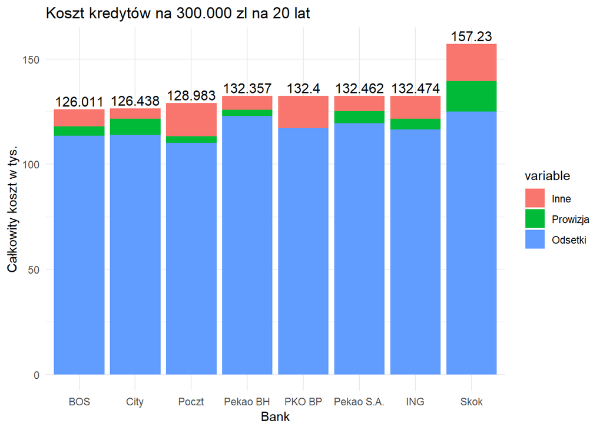

```r
dt2[,3] <- dt2[,3] / 1000
dt2$label <- dt1$Koszt
dt2[1:16,4] <- ""

ggplot(dt2, aes(x=Bank, y=value, fill=variable)) +
  geom_bar(stat="identity") +
  geom_text(aes(label = label, y = as.numeric(dt2[,4])),vjust=-0.3, color="black", size=4) +
  labs(y = "Całkowity koszt w tys.", title="Koszt kredytów na 300.000 zl na 20 lat") +
  theme_minimal()
```

## Pytania

### 1) Który bank ma najlepszą ofertę?

#### Przewidywania

Według przewidywań przy pierwszym wykresie odpowiedzi powinny być głównie błędne, informację tą bardzo ciężko odczytać bez wnikliwej analizy. W drugim przypadku powinniśmy dostać w większości prawidłowe odpowiedzi, gdyż przy każdym słupku widniała informacja o kosztach, ponadto banki były posortowane rosnąco po tej wartości.

#### Odpowiedzi

##### Wykres 1

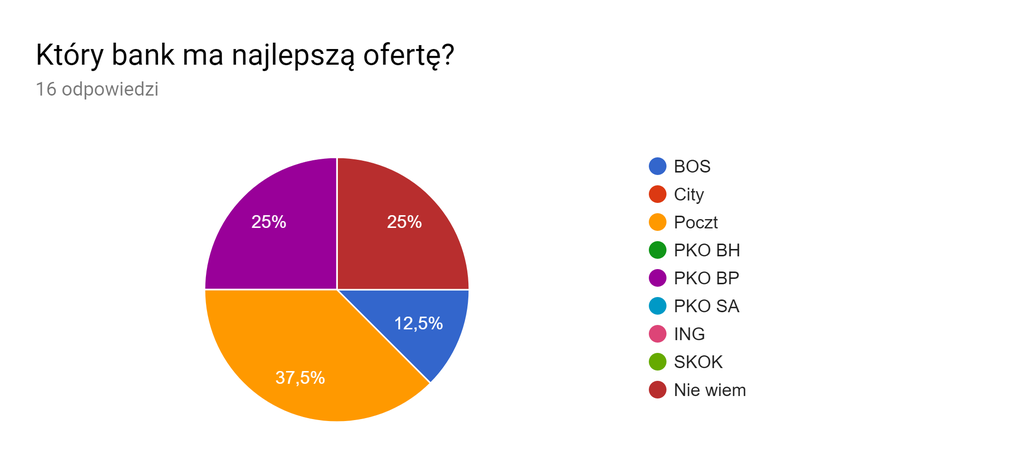

##### Wykres 2

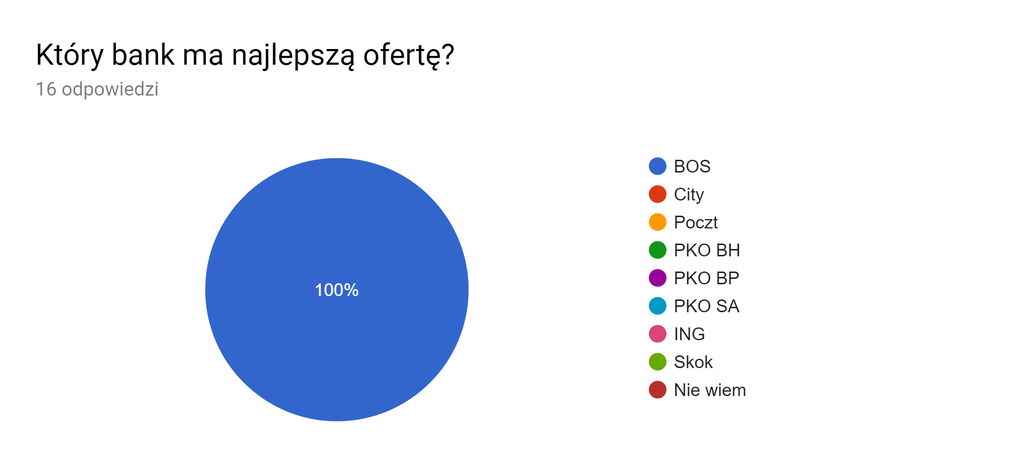

#### Komentarz

Przy pierwszym wykresie ankietowani raczej nie byli w stanie szybko znaleźć prawidłowej odpowiedzi. Część uznała, iż inforacji nie da się odczytać i zaznaczali opcję “nie wiem”. Reszta mimo trudności starała się coś wywnioskować z różnym skutkiem. Mimo wszytsko zdecydowana większość nie udzieliła poprawnej informacji. Informuje to nas o poważych trudnościach z odczytaniem tej informacji z tego wykresu.  
W drugim przypadku odpowiedzi były w 100% trafne. Oznacza to, iż dobrze przygotowaliśmy wykres. Najważniejsza informacja została przez wszytskich odczytana poprawnie.

### 2) Czy zauważyłeś, że Bank Pocztowy ma dwa razy większe koszty Innne niż BOS?

#### Przewidywania

Pytanie dotyczyło informacji bardzo łatwo widocznej na drugim wykresie i trochę trudniej (choć możliwej do odczytania po przyjrzeniu się) na wykresie drugim. Oczekujemy, iż przy pierwszym podejściu odsetek ankietowanych, którzy zauważyli tę zależność będzie znacznie mniejszy niż w drugim przypadku, ale nie koniecznie zerowy.

#### Odpowiedzi

##### Wykres 1

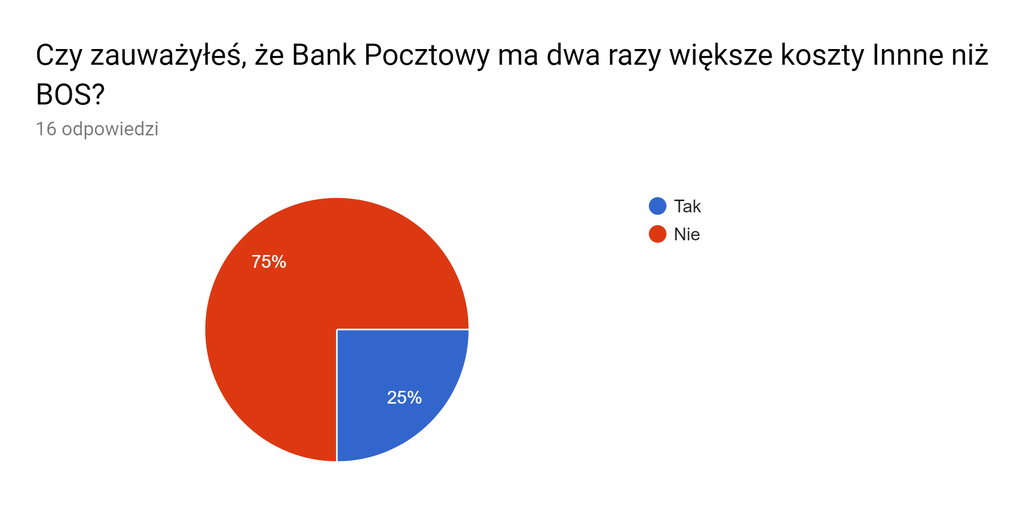

##### Wykres 2

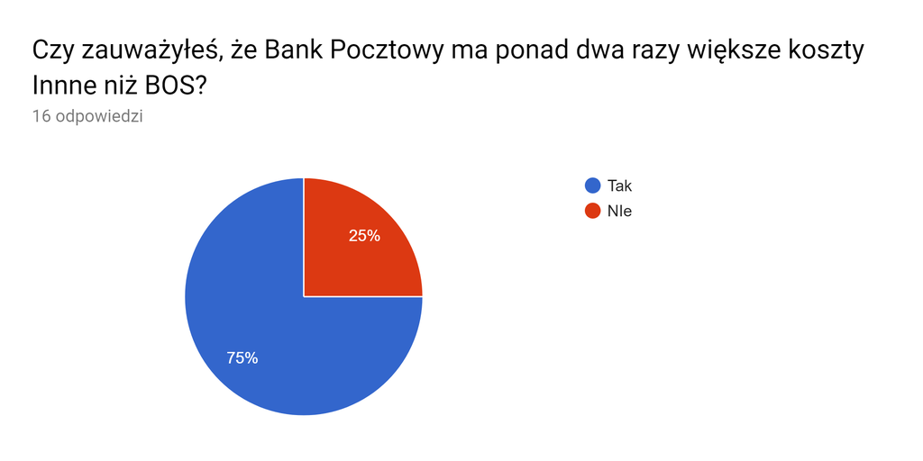

#### Komentarz

Zgodnie z oczekiwaniami, kilka osób ktore nie zostały zdemotywowanych formą pierwszego wykresu i poświęciły kilka sekund więcej poradziły sobie z zadaniem. Jednak większość odpowiedziała, iż nie zauważyła zależności. To pokazuje, iż w przypadku realnych czytelników znacznie częściej wystąpi druga sytuacja i takie szczegóły są zazwyczaj pomijane przy tak nieczytelnej formie. W drugim przypadku również nie było 100% odpowiedzi. Jest to zgodne z oczekiwaniami, gdyż większość osób, które nie stara się w tej chwili o kredyt, uważa takie informacje za mniej istotne i skupia się na innych.

### 3) Czy zauważyłeś, że SKOK ma zdecydowanie najgorszą ofertę?

#### Przewidywania

Ostatnie pytanie dotyczyło informacji, której zauważenie na pierwszym wykresie było łatwiejsze niż w dwóch poprzednich przypadkach, gdyż wszystkie trzy składowe SKOKu są najwyższe. Średnio wnikliwy obserwator bez problemu mógł je zsumować, ale wymaga to czasu i chęci. Oczekujemy, iż w pierwszym przypadku wynik nie będzie najgorszy, aczkolwiek w drugim będzie lepszy.

##### Wykres 1

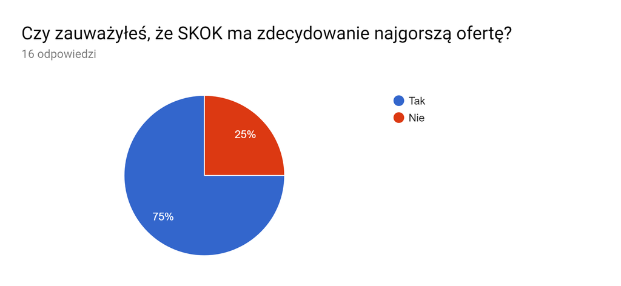

##### Wykres 2

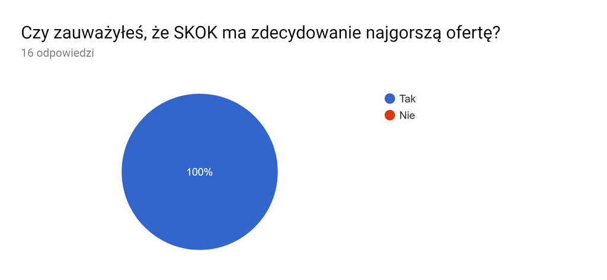

#### Komentarz

Zgodnie z oczekiwaniami, sporo osób zauważyła tą informację na pierwszym wykresie. W drugim przypadku odsetek ten był stuprocentowy.